# Genetic diversity indicators report for the GBF

## Introduction to genetic diversity

Genetic diversity is variation at the DNA level, and includes differences among individuals within populations of species, as well as differences between populations of species.

*Within populations*: the diversity within populations of a species helps a population adapt quickly to changing conditions, avoid inbreeding problems, and persist when environmental disturbances occur. Small populations will tend to lose genetic diversity more rapidly than large populations.

*Between populations*: the diversity between populations of a species is critical for ensuring the adaptive potential of that species (e.g. to a range of environmental conditions). Loss of any unique, genetically distinct populations can compromise a species’ ability to adapt to change (anthropogenic or otherwise).

It is therefore crucial that all populations be maintained, and that populations are sufficiently large to maintain genetic health. The genetic diversity indicators are based on these premises.

Genetic diversity within populations can be monitored by *the proportion of populations within species with an effective population size > 500* indicator (“Ne 500 indicator”).

Genetic diversity between populations can be monitored by the *proportion of populations maintained within species* indicator (“PM indicator”).

## Raw data used

The following files have the raw data used to produce the present report:

```r
# Get data:
indicators_full<-read.csv(file="indicators_full.csv")
indNe_data<-read.csv("indNe_data.csv")
```

Which country(ies) is(are) being analysed?

```
## [1] "mexico"
```

mexico has a total of 98 assessments (data entries in the Kobo form) where it was attempted to estimate the Ne 500 or PM indicators. These assessments where done in a total of 97 taxa (species or subspecies).

The number of assessments and the number of taxa can differ, because some taxa could have been assessed more than once, for example to account for different methods to define populations.

How many taxa were assessed (i.e. counting only once taxa that were assessed multiple times)?

```
## [1] 97
```

Which taxa where assessed more than once? (if any)

|  | country_assessment | taxonomic_group | taxon | scientific_authority | genus | year_assesment | name_assessor | email_assessor | common_name | kobo_tabular | X_validation_status | X_uuid | GBIF_taxonID | NCBI_taxonID | national_taxonID | source_national_taxonID | other_populations | time_populations | defined_populations | source_definition_populations | map_populations | map_populations_URL | habitat_decline_area | source_populations | popsize_data | ne_pops_exists | nc_pops_exists | ratio_exists | species_related | … |
| --- | --- | --- | --- | --- | --- | --- | --- | --- | --- | --- | --- | --- | --- | --- | --- | --- | --- | --- | --- | --- | --- | --- | --- | --- | --- | --- | --- | --- | --- | --- |
| 48 | mexico | mammal | Alouatta palliata mexicana | (Gray, 1849) | Alouatta | 2023 | Maria Camila Latorre Cárdenas | masshini@gmail.com | Mantled howler monkey | kobo | validation_status_approved | 248baaa8-df49-43ab-96e0-2b954dbda7ed | 2436649 | 30589 | 185365MAMIFB501112 | SNIB | unknown | No period | management_units | Experts opinion | Alouatta_palliata_mexicana_pop-23_21_46.jpg | https://kc.kobotoolbox.org/media/original?media_file=amastretta%2Fattachments%2Fb777f0bf79924d45ab7157705a420e5d%2F7f6e5542-70b0-47e2-9aad-f5ccaaeeafa5%2FAlouatta_palliata_mexicana_pop-23_21_46.jpg | NA | Experts: Liliana Cortés-Ortíz and Gilberto Pozo-Montuy\nSolórzano‐García, B., Zubillaga, D., Piñero, D., & Vázquez‐Domínguez, E. (2021). Conservation implications of living in\nforest remnants: inbree… | insuff_data_species | NA | NA | NA | NA | … |

## Key results for the Global Biodiversity Framework

### Headline indicator A.4 “The proportion of populations within species with an effective population size > 500” (“Ne 500 indicator”)

The “Ne 500 genetic diversity indicator” adopted at the Global Biodiversity Framework relates to [Goal A](https://www.cbd.int/gbf/goals): protect and restore; and [Target 4](https://www.cbd.int/gbf/targets/4): halt species extinction, protect genetic diversity, and manage human-wildlife conflicts.

Effective population size (Ne) is a well-accepted metric for measuring the genetic diversity within populations of wild species. An Ne above 500 (usually, but not always, equivalent to a census population size above 5,000) is widely viewed as sufficient to maintain genetic diversity within populations of a given species.

Populations that are small in size (effective population size Ne < 500) are highly susceptible to rapid loss of genetic diversity and are at high risk of extinction due to genetic threats.

See the [indicator GBF’s metadata](https://www.gbf-indicators.org/metadata/headline/A-4) for more details.

There was enough data to estimate the Ne 500 indicator in 47 taxa out of 97 assessed.

Considering only the taxa where it was possible to estimate the Ne 500 indicator, the indicator mean value for the country is 0.217075. That means that in 21.7% of the analysed populations are large enough to prevent the loss of genetic diversity.

Figure 1 shows:

- The total proportion of populations within each of the assessed species which have an effective population size (Ne) above 500 is shown in the bars. Each species is a bar. If a species has value of 0 it means that none of its populations is large enough to maintain genetic diversity. If a species has a vale of 1, it means that all of its populations are large enough to maintain genetic diversity (Ne > 500).
- The average taken across all species assessed for this indicator is indicated by the vertical dashed line.

#### Figure 1. Species-level proportion of populations above Ne 500

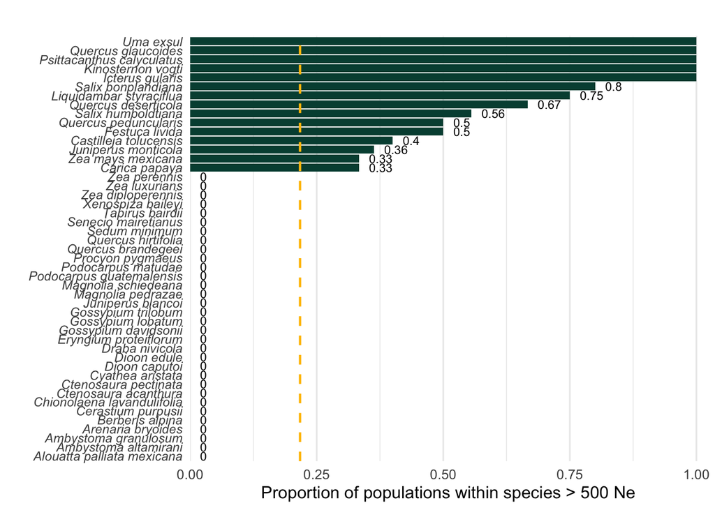

#### Figure 2. The frequency distribution of the Ne 500 indicator

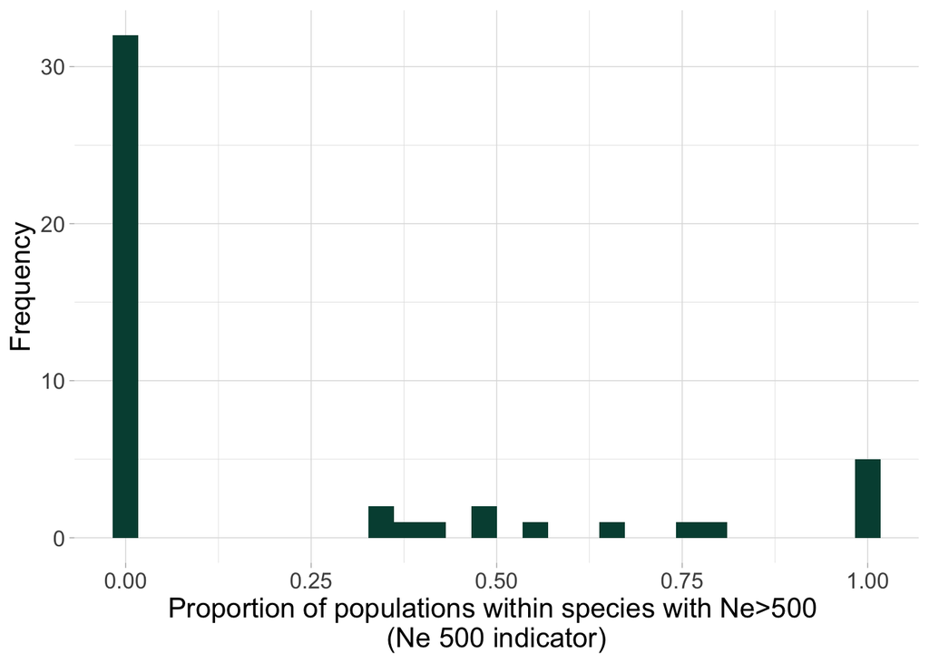

### Complementary indicator to Goal A “Proportion of populations maintained within species” (“PM indicator”)

In addition to the importance of within population genetic diversity, the diversity between populations is also critical. The populations maintained (PM) indicator measures the proportion of populations that still exist compared to the total number of populations that used to occur (i.e., it is a way of quantifying population extinctions). Each population is presumed to be genetically distinct and locally adapted–for example, due to harboring genetic variants that are either absent or rare in other populations. Therefore, loss of any population within a species equates to the loss of unique genetic diversity.

There was enough data to estimate the PM indicator in 28 taxa out of 97 assessed.

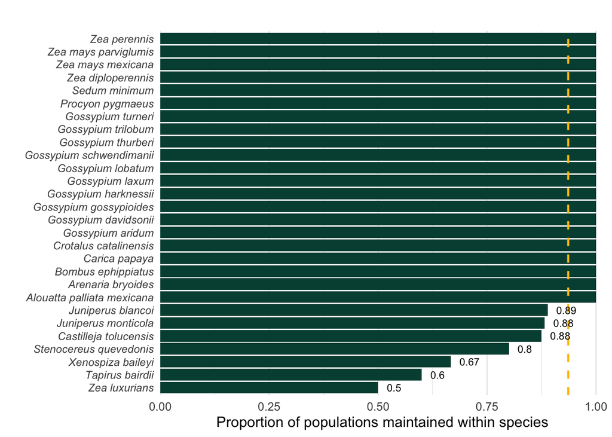

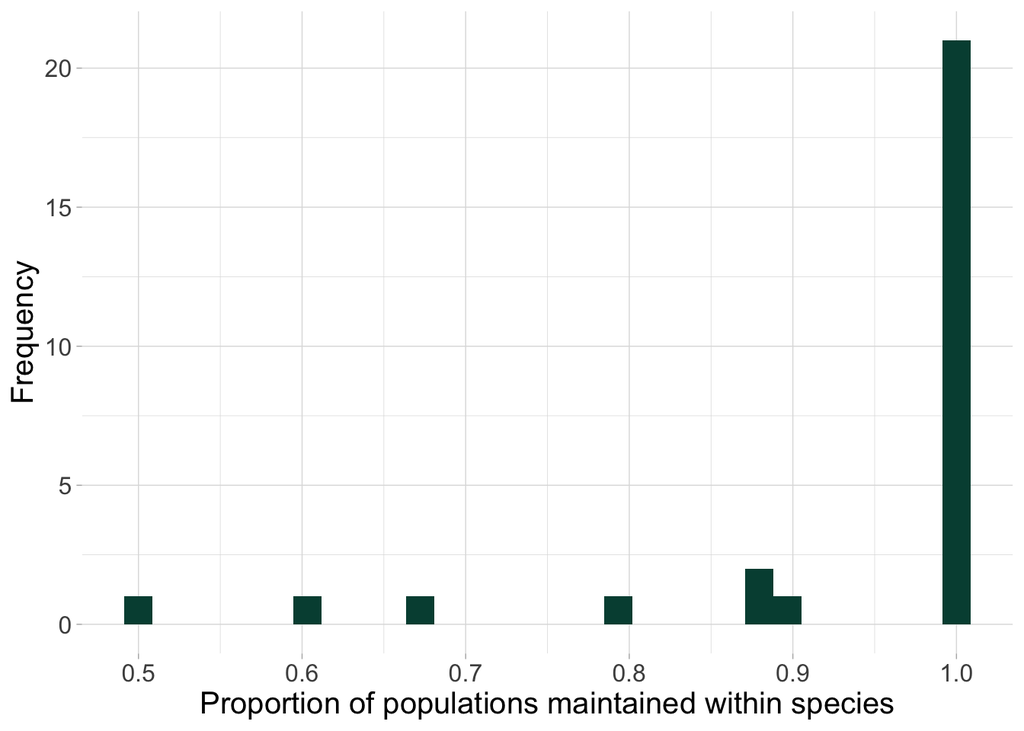

## Extra plots for detailed inspection of results

### General description of the dataset

### Taxonomic groups and endemicity

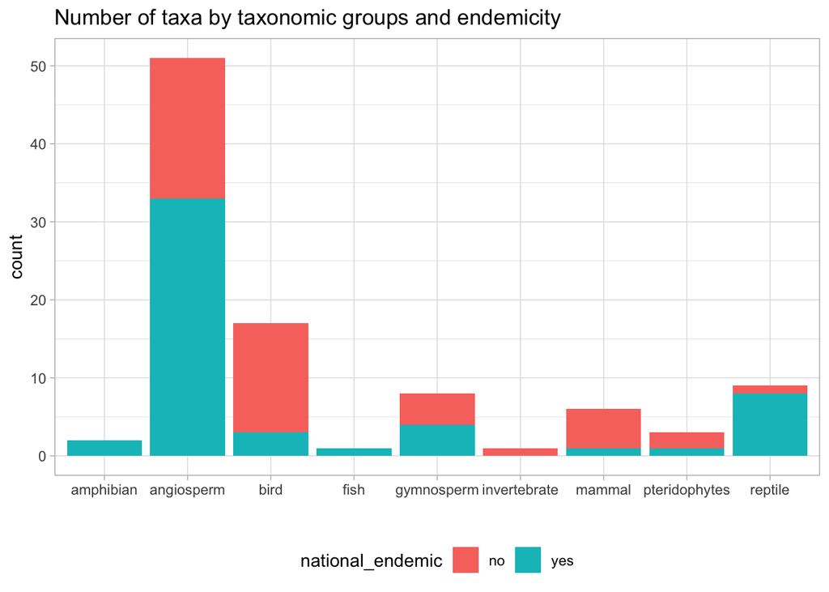

### Proportion of species distribution within the country

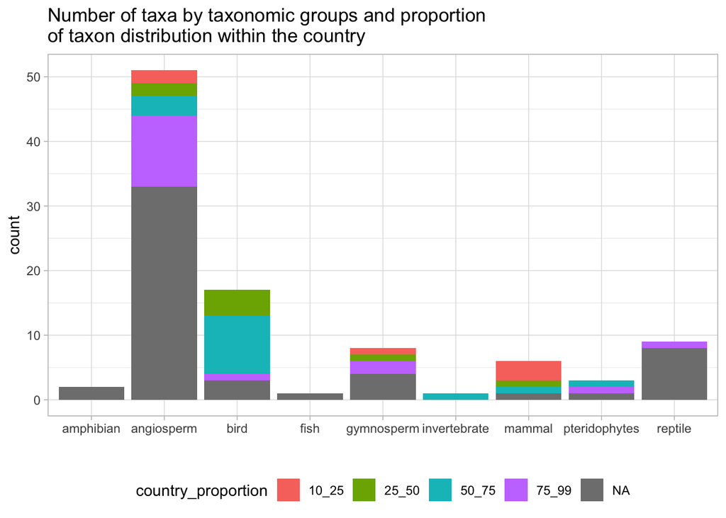

### Realm and habitat

Plot by Realm

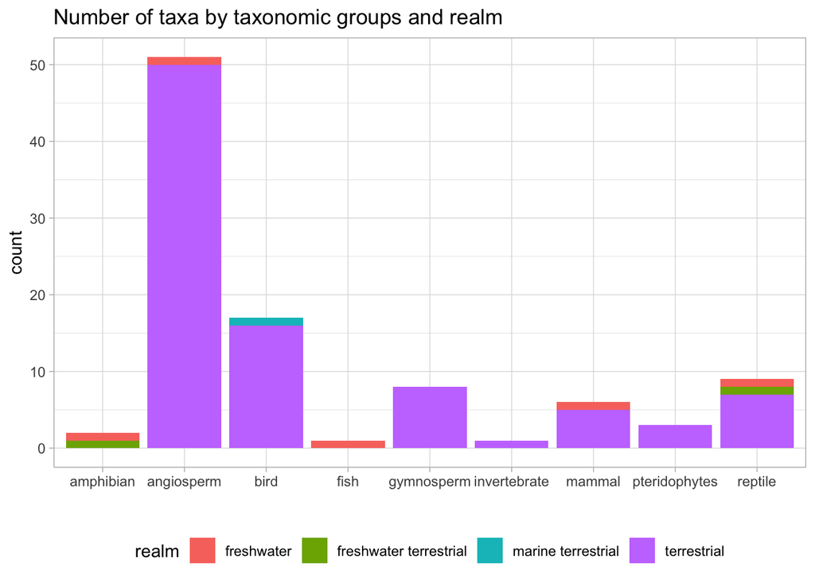

Habytat type as IUCN categories (a species can inhabit more than one type of habitat, that is why there are so many groups):

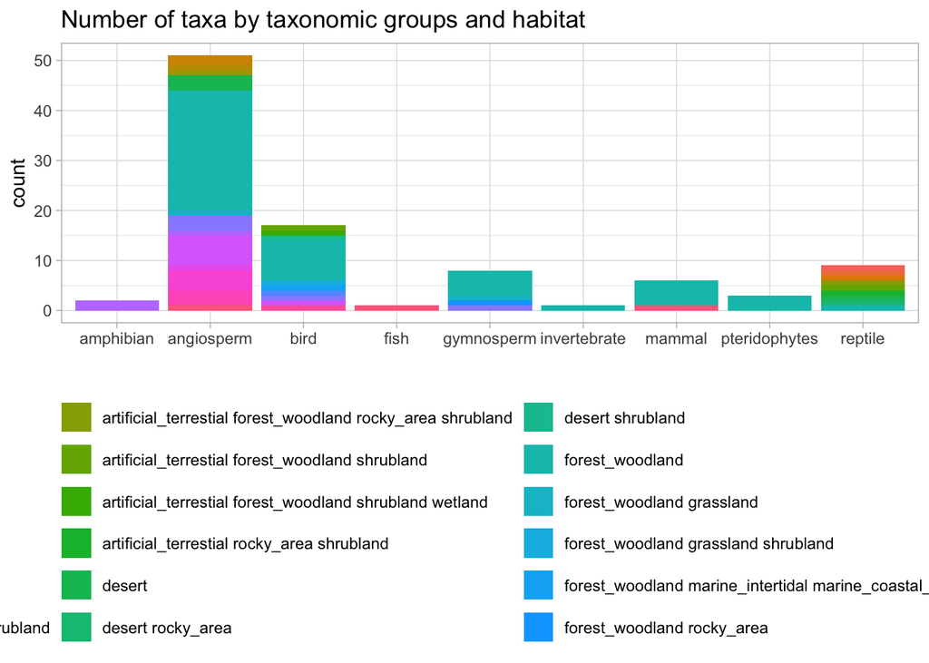

### Population size data availability

Population size (Nc or Ne) data availability at the taxon level:

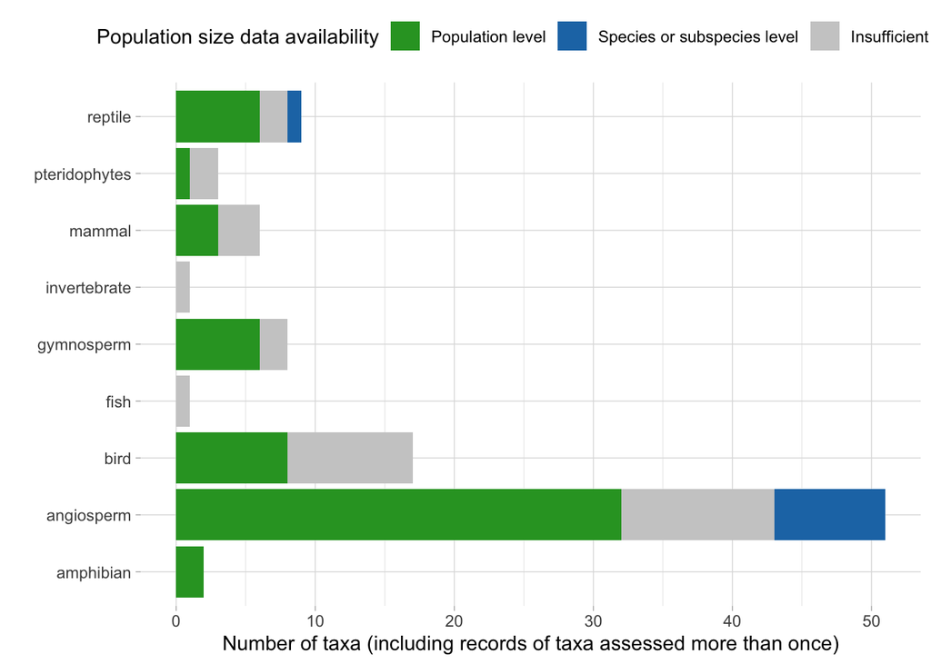

Ne available?

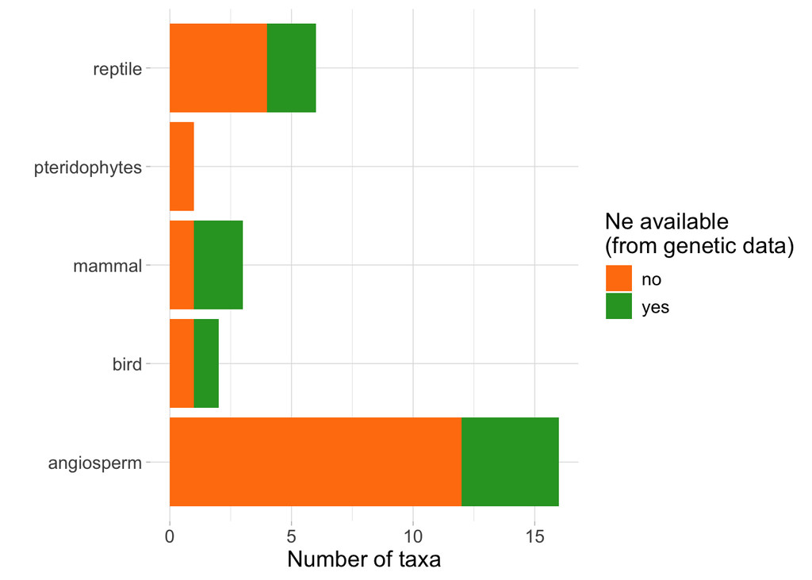

Nc data available by taxa?

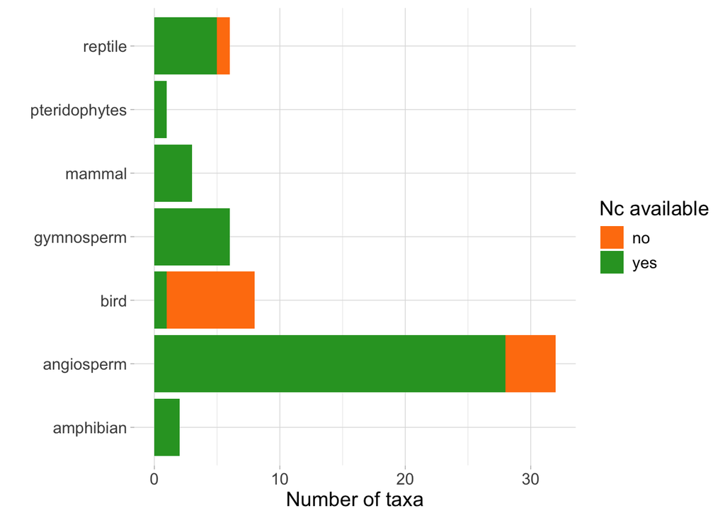

What kind of Nc data?

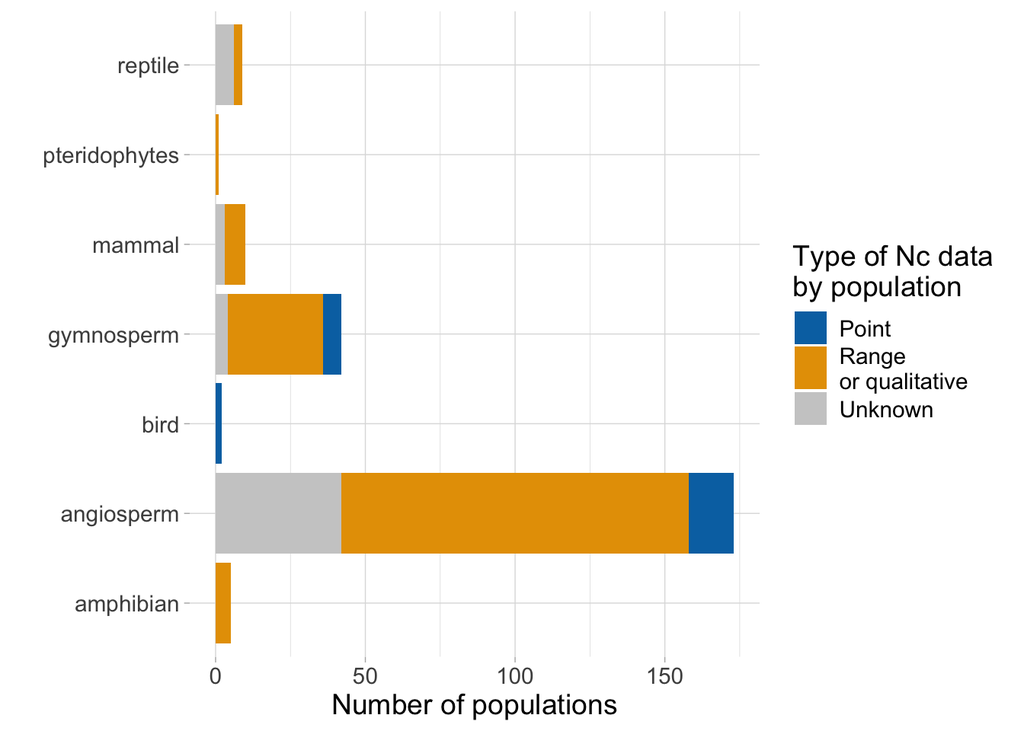

### Methods used to define populations

Frequency table of methods used to define population

```
##
##                                                           adaptive_traits
##                                                                         1
##                                          adaptive_traits management_units
##                                                                         1
##                                                        eco_biogeo_proxies
##                                                                         2
##                                                  eco_biogeo_proxies other
##                                                                         1
##                                                          genetic_clusters
##                                                                        33
##                                          genetic_clusters adaptive_traits
##                                                                         3
##                                       genetic_clusters eco_biogeo_proxies
##                                                                         7
##                       genetic_clusters eco_biogeo_proxies adaptive_traits
##                                                                         2
##                                    genetic_clusters geographic_boundaries
##                                                                        13
##                    genetic_clusters geographic_boundaries adaptive_traits
##                                                                         2
##                 genetic_clusters geographic_boundaries eco_biogeo_proxies
##                                                                         1
## genetic_clusters geographic_boundaries eco_biogeo_proxies adaptive_traits
##                                                                         1
##                                                     geographic_boundaries
##                                                                        15
##                                     geographic_boundaries adaptive_traits
##                                                                        10
##                                  geographic_boundaries eco_biogeo_proxies
##                                                                         1
##                                               geographic_boundaries other
##                                                                         1
##                                                          management_units
##                                                                         1
##                                                    management_units other
##                                                                         1
##                                                                     other
##                                                                         2
```

### Plot number of populations by method

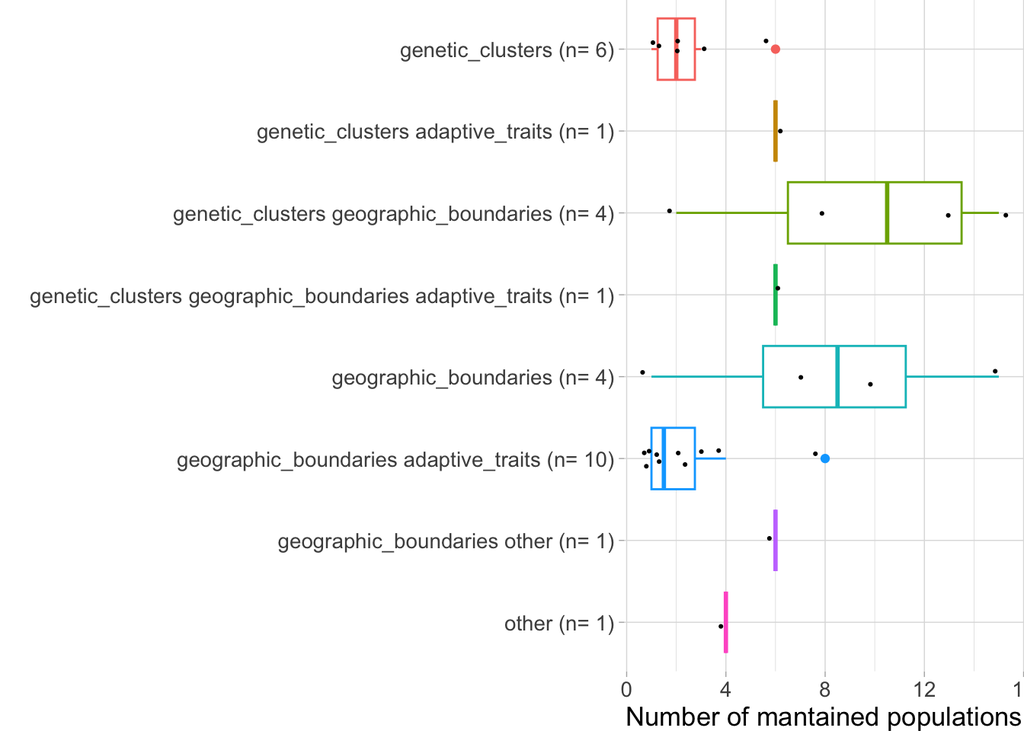

### Missing data on extant and extinct populations

We have NA in indicator PM because in some cases the number of extinct populations is unknown, therefore the operation cannot be computed.

### Counts

Total records with NA in extant populations:

```
## [1] 5
```

Taxa with NA in extant populations:

| taxonomic_group | taxon | n_extant_populations | n_extinct_populations |
| --- | --- | --- | --- |
| reptile | Ctenosaura macrolopha | NA | NA |
| gymnosperm | Pinus ayacahuite | NA | NA |
| bird | Egretta rufescens dickeyi | NA | NA |
| reptile | Kinosternon integrum | NA | NA |
| reptile | Abronia deppii | NA | NA |

Total taxa with NA in **extinct** populations:

```
## [1] 70
```

Do taxa with NA for extant also have NA for extinct?

```
## [1] TRUE TRUE TRUE TRUE TRUE
```

### Plot missing data extinct populations

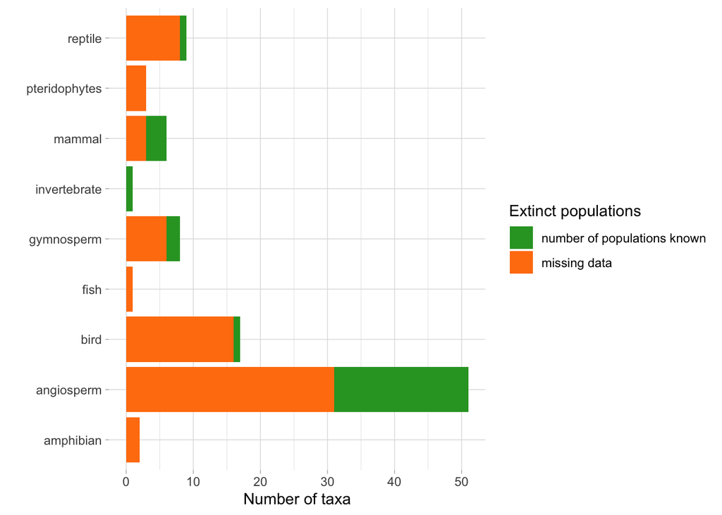

### Ne > 500 indicator

In total, there was data to compute the Ne indicator in the following number of taxa:

```r
sum(!is.na(indicators_full$indicatorNe))
```

```
## [1] 47
```

Considering those 47 taxa, the Ne indicator mean value for the country is:

```
## [1] 0.217075
```

### Ne > 500 by type of range

By type of range in the entire dataset:

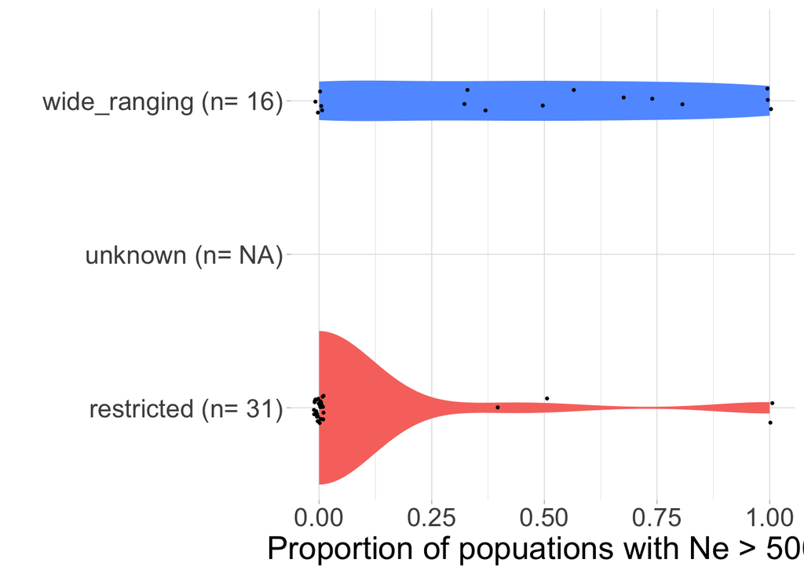

### Ne > 500 by IUCN status

By global IUCN:

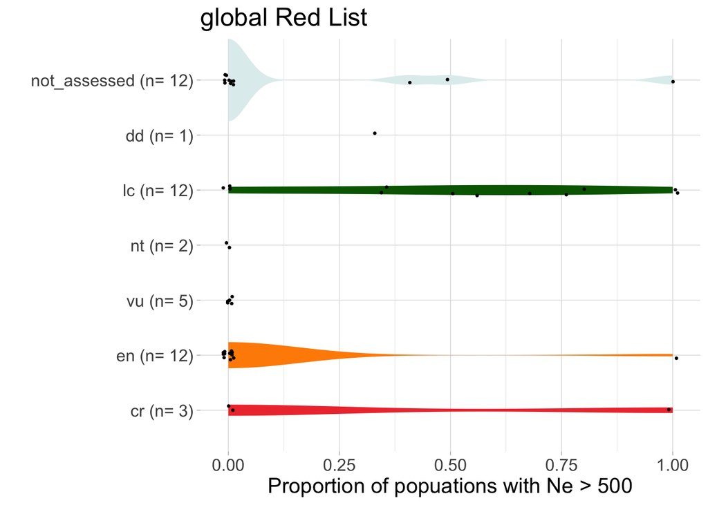

By regional IUCN (this may make no sense for your country if there is no IUCN redlist assessments at regional level:

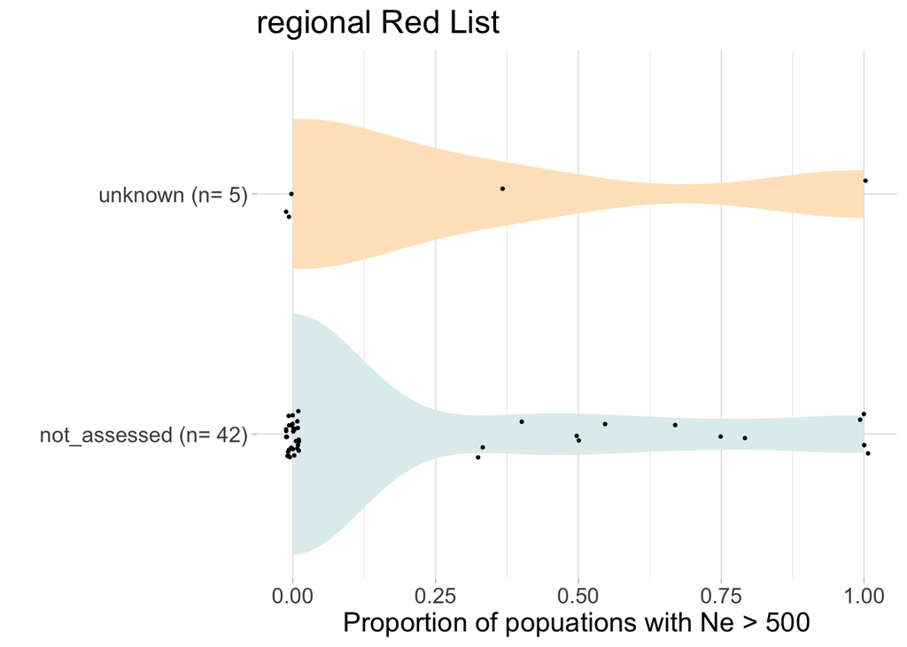

### Ne > 500 by endemicity

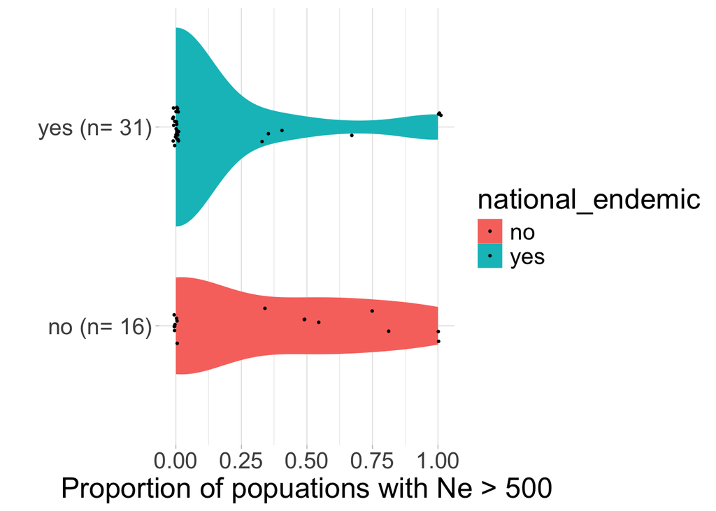

### Distribution of Ne values

How is Ne data distributed?

```
##     Min.  1st Qu.   Median     Mean  3rd Qu.     Max.     NA's
##      1.9     19.9     45.5  22915.0    133.9 331400.0      281
```

Boxplot of Ne values:

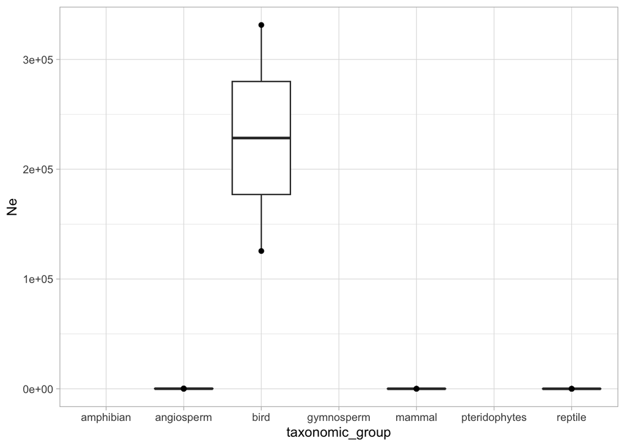

Check outliers (Ne very high):

| country_assessment | name_assessor | taxon | taxonomic_group | Ne | NeLower | NeUpper | multiassessment | population |
| --- | --- | --- | --- | --- | --- | --- | --- | --- |
| mexico | Alexander Llanes Quevedo | Icterus gularis | bird | 125500 | 122000 | 128000 | single_assessment | pop1 |
| mexico | Alexander Llanes Quevedo | Icterus gularis | bird | 331400 | 324000 | 338000 | single_assessment | pop2 |

Ne Boxplot filtering outliers (if any)

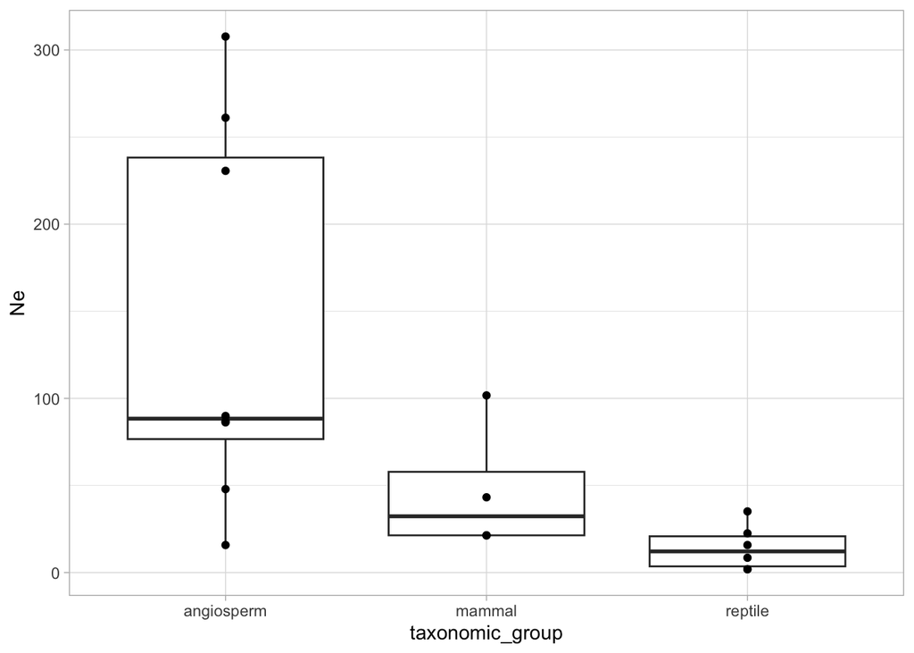

### Distribution of Nc values and ranges

Point data

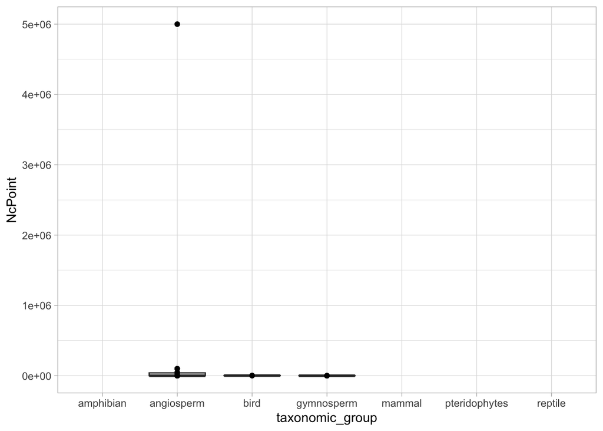

Range data (categorical):

```
##
##           less_5000    less_5000_bymuch           more_5000    more_5000_bymuch
##                  29                 104                  16                  13
## range_includes_5000
##                   2
```

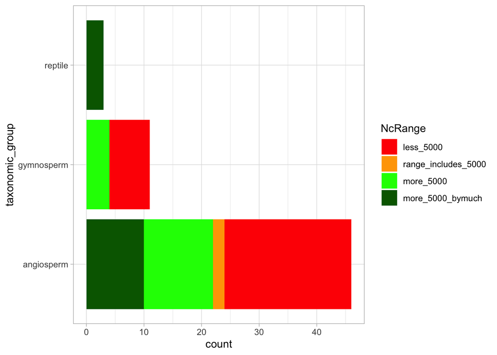

### Proportion of populations mantained (PM indicator)

#### Plot Proportion of populations mantained (PM indicator) by method

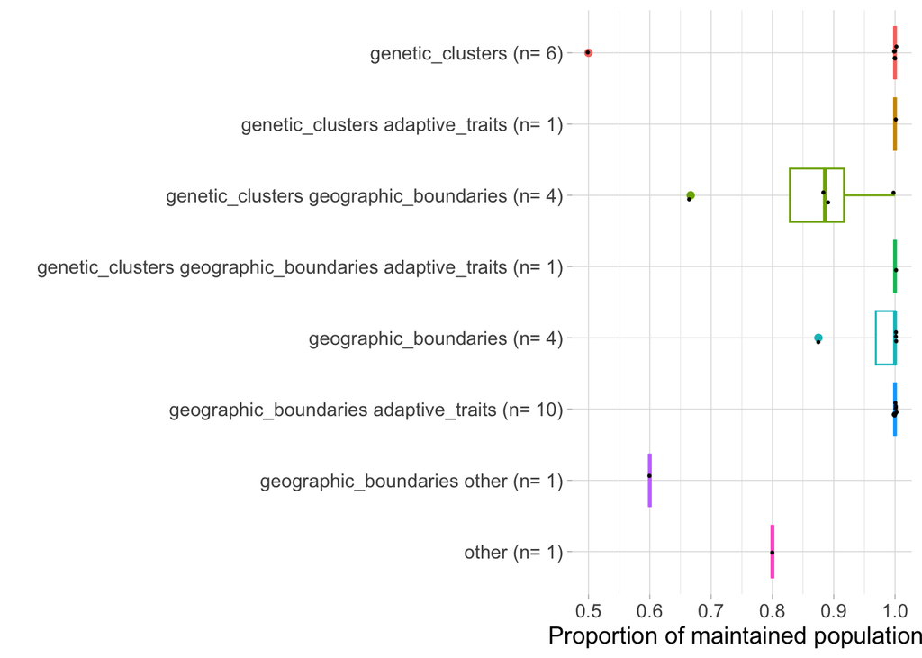

#### by type of range

By type of range in the entire dataset:

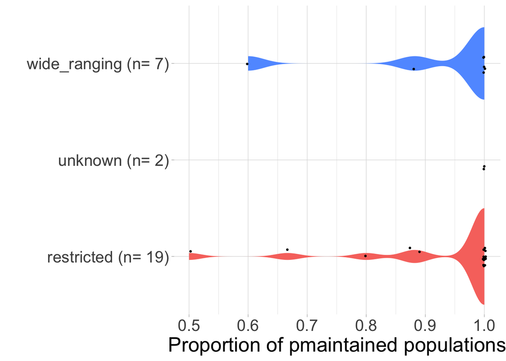

#### by IUCN status

By global IUCN:

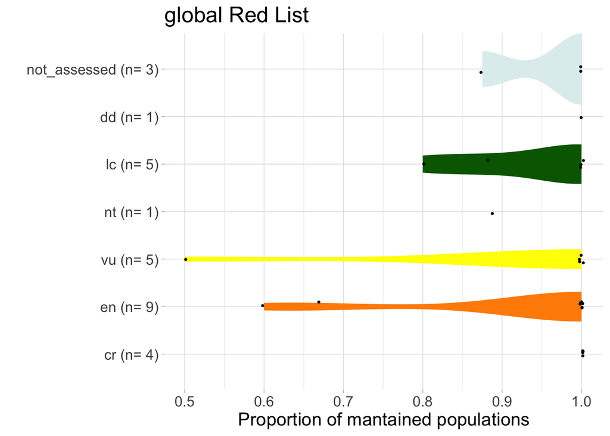

By regional IUCN (this may make no sense for your country if there is no IUCN redlist assessments at regional level:

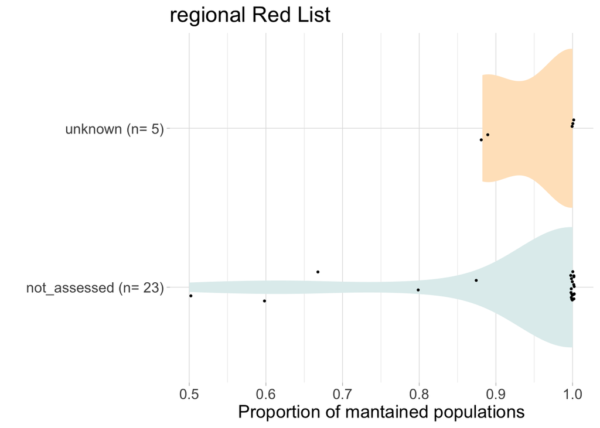

#### Proportion of maintained populations by endemicity

[figure not shown]

#### Plot Scatter plot of indicatorPM and extant pops

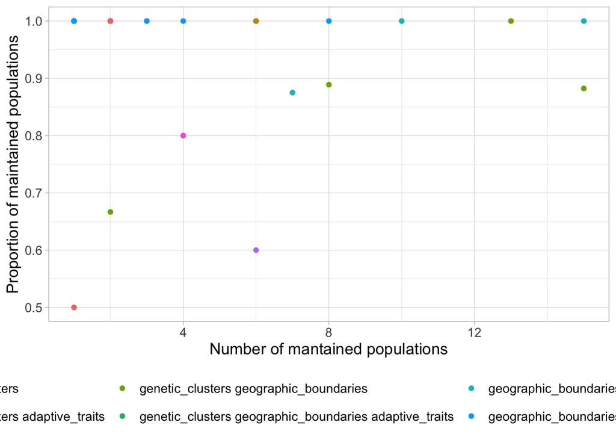